# Cord Blood Quality Control with DropletQC

Author

Valerio Reffo

Published

June 6, 2028

```r
library(DropletQC)
library(purrr)
library(ggplot2)
library(patchwork)
library(dplyr)
library(scuttle)
library(scran)
library(scater)
library(anndataR)
library(SingleCellExperiment)
```

## Data Loading and Initial Per-Cell QC

We load the calculated nuclear fraction data along with the main Cord Blood `SingleCellExperiment` object. We also calculate standard mitochondrial QC metrics.

```r
sce_cb <- readRDS("/projects/shared/intronic_bam/datasets/cord_blood/cord_blood_sce.RDS")
sce_cb
```

```
class: SingleCellExperiment
dim: 20400 7858
metadata(0):
assays(2): counts logcounts
rownames(20400): A1BG A1BG-AS1 ... hsa-mir-7515 hsa-mir-8072
rowData names(1): subsets_Mito
colnames(7858): TACAGTGTCTCGGACG GTTTCTACATCATCCC ... TTGCCGTGTAGATTAG
  GGCGTGTAGTGTACTC
colData names(18): adt.discard mito.discard ... sizeFactor cell_status
reducedDimNames(4): scGPT PCA UMAP UMAP_embed
mainExpName: NULL
altExpNames(1): scADT
```

Let’s read the anndata with the embeddings matrix

```r
# Path automatically adapted for Cord Blood
cb_ann <- read_h5ad("/projects/shared/intronic_bam/datasets/anndata/cb_scGPT_embeddings.h5ad")
cb_ann
```

Add it into the reducedDim slot of the sce

```r
scgpt_matrix <- as.matrix(cb_ann$obsm['X_scGPT']$X_scGPT)
scgpt_matrix_aligned <- scgpt_matrix[colnames(sce_cb), ]
reducedDim(sce_cb, "scGPT") <- scgpt_matrix_aligned
reducedDimNames(sce_cb)
```

### Mitochondrial Metrics Calculation

We identify mitochondrial genes based on the `MT-` prefix to compute per-cell quality control metrics.

```r
# Identify mitochondrial genes based on rownames
is_mito <- grepl("^MT-", rownames(sce_cb), ignore.case = TRUE)
summary(is_mito) # Verification of detected mitochondrial genes

# Automatically calculate and append QC metrics to colData
sce_cb <- addPerCellQC(sce_cb, subsets = list(Mito = is_mito))
```

## Aligning and Integrating Nuclear Fraction

```r
# Review cell type composition
table(sce_cb$celltype)
```

```
        B-cells     CD4 T-cells     CD8 T-cells Monocytes CD14+ Monocytes CD16+
            340            3262             354            2411             143
Natural Killers      Precursors         T-cells
           1029             115              46
```

## Exploratory Analysis and Distributions

We visualize the distribution of the nuclear fraction across different cell types and evaluate its relationship with total UMI counts.

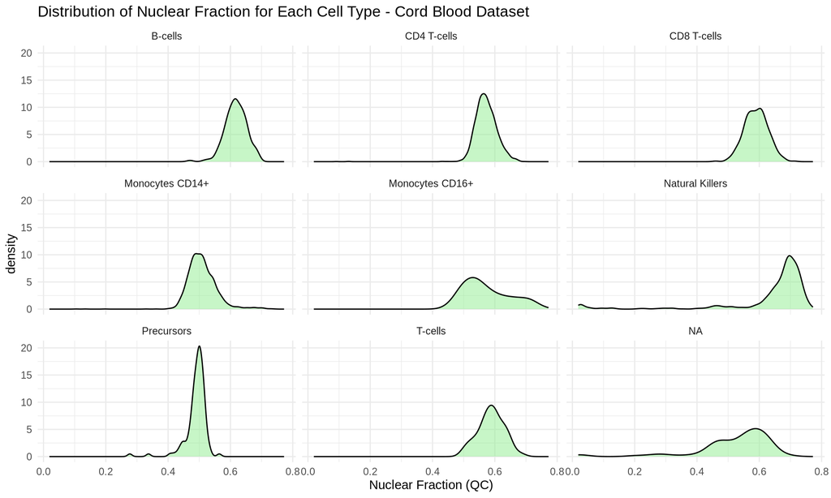

```r
# Distribution of nuclear fraction per cell type
p <- ggplot(as.data.frame(colData(sce_cb)), aes(x = nuclear_fraction))

p + geom_density(fill = "lightgreen", alpha = 0.5) +
  facet_wrap(~celltype) +
  theme_minimal() +
  labs(title = "Distribution of Nuclear Fraction for Each Cell Type - Cord Blood Dataset",
       x = "Nuclear Fraction (QC)")
```

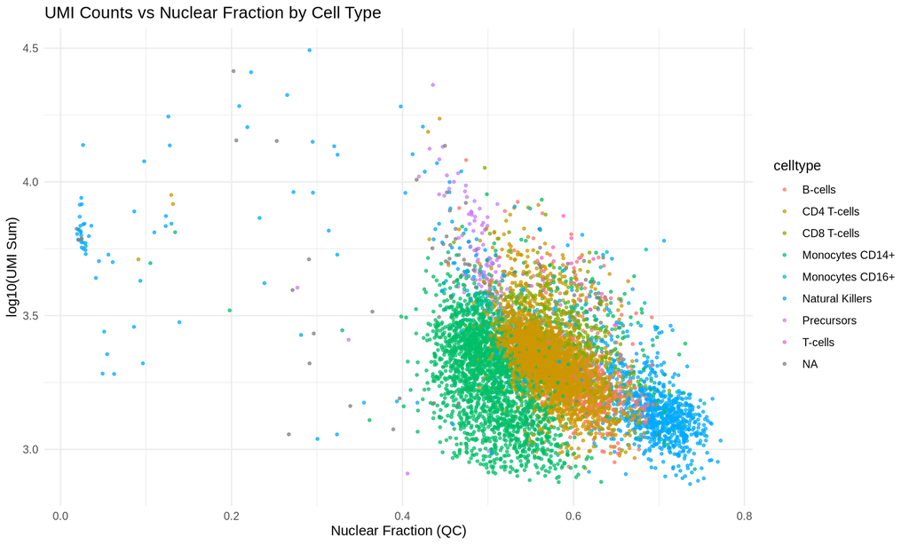

```r
# Distribution of UMI counts mapped over the cell types
p + aes(y = log10(sum), colour = celltype) +
  geom_point(alpha = 0.7, size = 0.8) +
  theme_minimal() +
  labs(title = "UMI Counts vs Nuclear Fraction by Cell Type",
       x = "Nuclear Fraction (QC)",
       y = "log10(UMI Sum)")
```

## Normalization and Dimensionality Reduction

We perform log-normalization, model the gene variance to select the Top 10% highly variable genes (HVGs), and generate PCA and UMAP embeddings.

```r
sce_cb <- logNormCounts(sce_cb)
dec <- modelGeneVar(sce_cb)
hvgs <- getTopHVGs(dec, prop = 0.1)

sce_cb <- runPCA(sce_cb, subset_row = hvgs, ncomponents = 50)
sce_cb <- runUMAP(sce_cb, dimred = "PCA")
sce_cb
```

Let’s calculate the UMAP on the embeddings too

```r
sce_cb <- runUMAP(sce_cb, dimred = "scGPT", name = "UMAP_embed")
```

### Embedding Visualization (PCA vs UMAP)

We display the low-dimensional spaces colored by cell type and by our updated nuclear fraction metric.

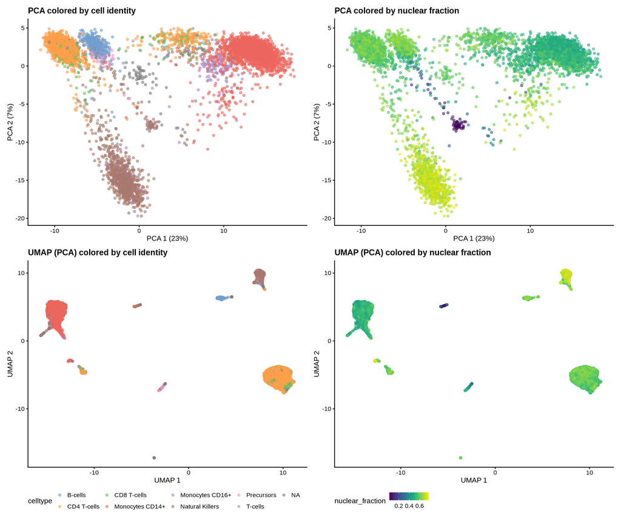

```r
# Cell identity
umapp <- plotUMAP(sce_cb, colour_by = "celltype", dimred = "UMAP") +
  theme(legend.position = "bottom") +
  labs(title = "UMAP (PCA) colored by cell identity")
pcap  <- plotPCA(sce_cb, colour_by = "celltype") +
  theme(legend.position = "none") +
  labs(title = "PCA colored by cell identity")

# Nuclear Fraction
umapb <- plotUMAP(sce_cb, colour_by = "nuclear_fraction", dimred = "UMAP") +
  theme(legend.position = "bottom") +
  labs(title = "UMAP (PCA) colored by nuclear fraction")
pcab  <- plotPCA(sce_cb, colour_by = "nuclear_fraction") +
  theme(legend.position = "none") +
  labs(title = "PCA colored by nuclear fraction")

# Umap embeddings
umapes <- plotUMAP(sce_cb, colour_by = "celltype", dimred = "UMAP_embed") +
  theme(legend.position = "bottom") +
  labs(title = "UMAP (Embeddings) colored by cell identity")
umape <- plotUMAP(sce_cb, colour_by = "nuclear_fraction", dimred = "UMAP_embed") +
  theme(legend.position = "bottom") +
  labs(title = "UMAP (Embeddings) colored by nuclear fraction")

# Composite layout
(pcap | pcab) / (umapp | umapb)
```

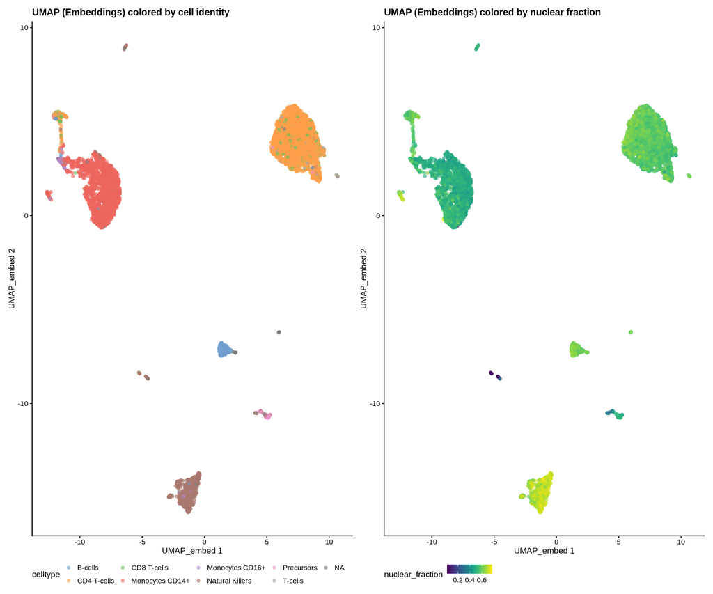

```r
(umapes | umape)
```

## Investigating MALAT1 and Nuclear Fraction Relationship

MALAT1 is absent in cordblood

```r
# Check feature expression on UMAP and PCA
umapm <- plotUMAP(sce_cb, colour_by = "MALAT1")
pcam  <- plotPCA(sce_cb, colour_by = "MALAT1")

# Side-by-side comparison with nuclear fraction
pcab | pcam
umapb | umapm
```

### MALAT1 vs Nuclear Fraction Scatter Plot

```r
plotExpression(sce_cb,
               features = "MALAT1",
               x = "nuclear_fraction",
               other_fields = "celltype",
               exprs_values = "logcounts") +
  facet_wrap(~celltype) +
  aes(color = celltype) +
  theme_minimal() +
  labs(title = "MALAT1 vs Nuclear Fraction per Cell Type",
       x = "Nuclear Fraction (QC)",
       y = "MALAT1 Expression (logcounts)")
```

## Empty Droplet and Damaged Cell Identification

Using `DropletQC`, we extract the nuclear fraction and total UMI counts to identify and flag potential empty droplets.

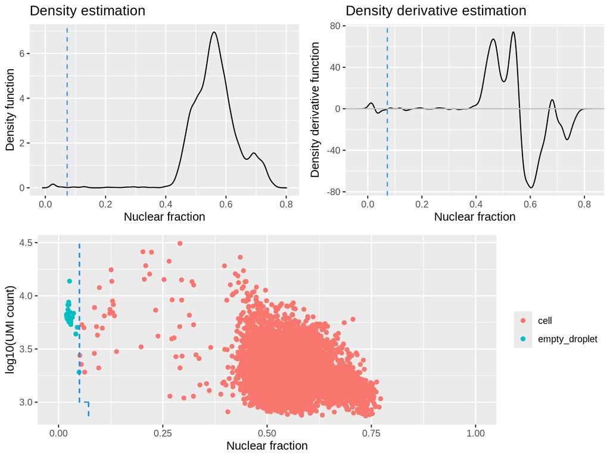

```r
# Prepare the input data frame
nf_umi <- data.frame(
  nf = sce_cb$nuclear_fraction,
  umi = sce_cb$sum,
  celltype = sce_cb$celltype
)

rownames(nf_umi) <- colnames(sce_cb)

# Handle NA values
nf_umi <- nf_umi[!is.na(nf_umi$nf),]

# Re-run to generate diagnostic plots and visualize the threshold cut-offs
cb_ed <- identify_empty_drops(nf_umi = nf_umi, include_plot = TRUE)
```

```r
# Summary table of cell status
table(cb_ed$cell_status)
```

```
         cell empty_droplet
         7826            32
```

## Investigation of possible association between empty droplets and cell identity

Add the cell status column in the coldata of sce_cb. Note that MALAT1 is absent in this dataset, so we only evaluate the nuclear fraction distribution.

```r
sce_cb$cell_status <- cb_ed[colnames(sce_cb), "cell_status"]
```

```r
table(sce_cb$celltype, sce_cb$cell_status)
```

[output not shown]

[figure not shown]

```r
p1 <- sce_cb[, !is.na(sce_cb$cell_status)] |>
  ggcells(aes(x = cell_status, y = nuclear_fraction, fill = cell_status)) +
  geom_boxplot(alpha = 0.7, outlier.size = 0.5) +
  facet_wrap(~ celltype) +
  theme_minimal() +
  labs(
    title = "Nuclear fraction distribution for cell status",
    subtitle = "By each cell identity",
    x = "Cell Status",
    y = "Nuclear Fraction",
    fill = "Status"
  )

p1
```

## Damaged Cell Identification

```r
# Reorder columns with relocate using celltype
cb_ed <- cb_ed |>
  relocate(celltype, .after = cell_status)

# Detect damaged cell populations
cb_ed_dc <- identify_damaged_cells(cb_ed, verbose = FALSE, output_plots = TRUE)

# Final cell status summary
table(cb_ed_dc[[1]]$cell_status)
```

```
         cell  damaged_cell empty_droplet
         6903           923            32
```

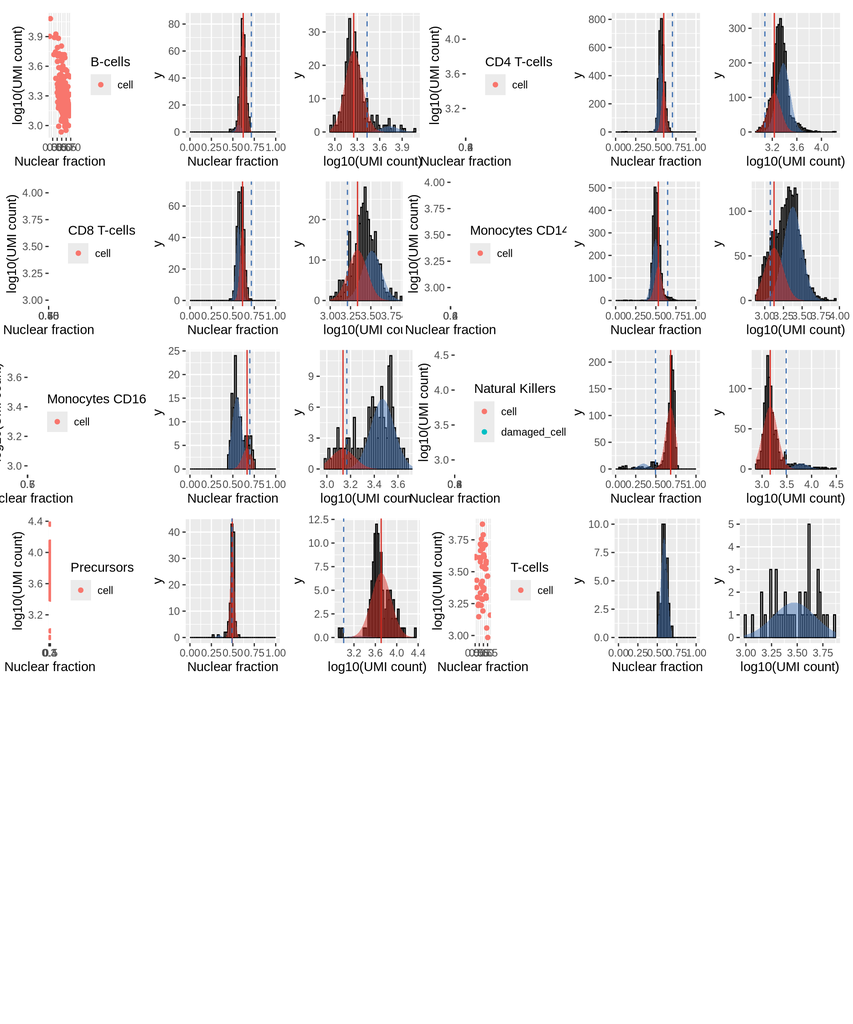

```r
# Diagnostic plots for each cell identity group
wrap_plots(cb_ed_dc[[2]], nrow = 6)
```

Add again in the single cell experiment

```r
sce_cb$cell_status <- cb_ed_dc[[1]][colnames(sce_cb), "cell_status"]
```

```r
table(sce_cb$celltype, sce_cb$cell_status)
```

```
                  cell damaged_cell empty_droplet
  B-cells          340            0             0
  CD4 T-cells     3262            0             0
  CD8 T-cells      354            0             0
  Monocytes CD14+ 2411            0             0
  Monocytes CD16+  143            0             0
  Natural Killers   78          923            28
  Precursors       115            0             0
  T-cells           46            0             0
```

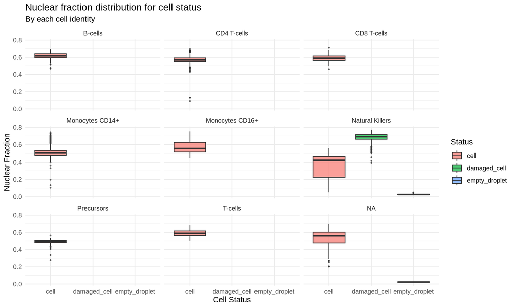

```r
p1 <- sce_cb[, !is.na(sce_cb$cell_status)] |>
  ggcells(aes(x = cell_status, y = nuclear_fraction, fill = cell_status)) +
  geom_boxplot(alpha = 0.7, outlier.size = 0.5) +
  facet_wrap(~ celltype) +
  theme_minimal() +
  labs(
    title = "Nuclear fraction distribution for cell status",
    subtitle = "By each cell identity",
    x = "Cell Status",
    y = "Nuclear Fraction",
    fill = "Status"
  )

p1
```

# Last plots: UMAP damaged and empty droplets

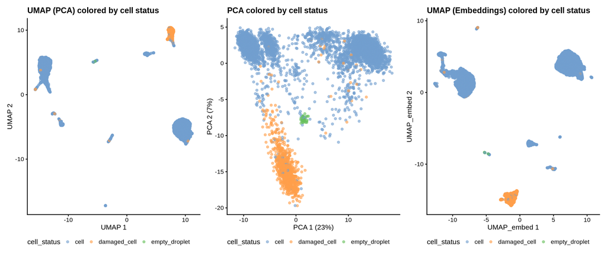

```r
umapc <- plotUMAP(sce_cb, colour_by = "cell_status") + theme(legend.position = "bottom") +
  labs(title = "UMAP (PCA) colored by cell status")
pcam  <- plotPCA(sce_cb, colour_by = "cell_status") + theme(legend.position = "bottom") +
  labs(title = "PCA colored by cell status")
umapec <- plotUMAP(sce_cb, colour_by = "cell_status", dimred = "UMAP_embed") + theme(legend.position = "bottom") +
  labs(title = "UMAP (Embeddings) colored by cell status")

umapc | pcam | umapec
```

and the relationship between cell status and cell types in the embeddings

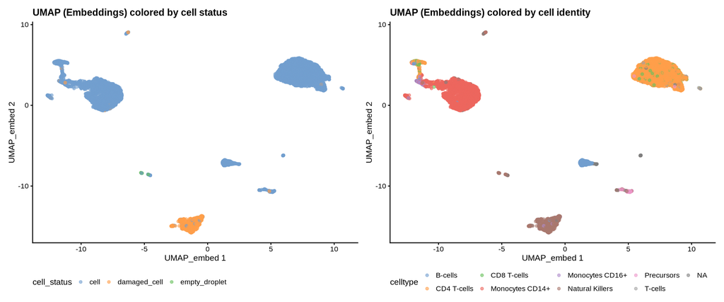

```r
umapec | umapes
```